# Will a data scientist leave your company?

# Feature Selection

We will compare how the correlation matrix has changed after the data preprocessing in contrast to the initial one because we am want to know how the correlation of independent features has changed after data preprocessing.

```python
df.head()
```

|  | enrollee_id | city | city_development_index | gender | relevent_experience | enrolled_university | education_level | major_discipline | experience | company_size | company_type | last_new_job | training_hours | target |
| --- | --- | --- | --- | --- | --- | --- | --- | --- | --- | --- | --- | --- | --- | --- |
| 0 | 32403 | city_41 | 0.827 | Male | Has relevent experience | Full time course | Graduate | STEM | 9 | <10 | NaN | 1 | 21 | NaN |
| 1 | 9858 | city_103 | 0.920 | Female | Has relevent experience | no_enrollment | Graduate | STEM | 5 | NaN | Pvt Ltd | 1 | 98 | NaN |
| 2 | 31806 | city_21 | 0.624 | Male | No relevent experience | no_enrollment | High School | NaN | <1 | NaN | Pvt Ltd | never | 15 | NaN |
| 3 | 27385 | city_13 | 0.827 | Male | Has relevent experience | no_enrollment | Masters | STEM | 11 | 10/49 | Pvt Ltd | 1 | 39 | NaN |
| 4 | 27724 | city_103 | 0.920 | Male | Has relevent experience | no_enrollment | Graduate | STEM | >20 | 10000+ | Pvt Ltd | >4 | 72 | NaN |

```python
# label encoding of the initial dataset
df_filled = filling_missing_values(df)
```

```python
df_filled.head()
```

|  | enrollee_id | city_development_index | training_hours | target | city | gender | relevent_experience | enrolled_university | education_level | major_discipline | experience | company_size | company_type | last_new_job |
| --- | --- | --- | --- | --- | --- | --- | --- | --- | --- | --- | --- | --- | --- | --- |
| 0 | 32403 | 0.827 | 21 | NaN | 78 | 1 | 0 | 0 | 0 | 5 | 19 | 7 | 6 | 0 |
| 1 | 9858 | 0.920 | 98 | NaN | 5 | 0 | 0 | 3 | 0 | 5 | 15 | 8 | 5 | 0 |
| 2 | 31806 | 0.624 | 15 | NaN | 64 | 1 | 1 | 3 | 1 | 6 | 20 | 8 | 5 | 6 |
| 3 | 27385 | 0.827 | 39 | NaN | 26 | 1 | 0 | 3 | 2 | 5 | 2 | 0 | 5 | 0 |
| 4 | 27724 | 0.920 | 72 | NaN | 5 | 1 | 0 | 3 | 0 | 5 | 21 | 3 | 5 | 4 |

```python
#choosing the most important features from the initial dataset
df_initial = df_filled[['city_development_index', 'relevent_experience', 'enrolled_university',
             'education_level', 'experience', 'last_new_job', 'company_size', 'target']]
```

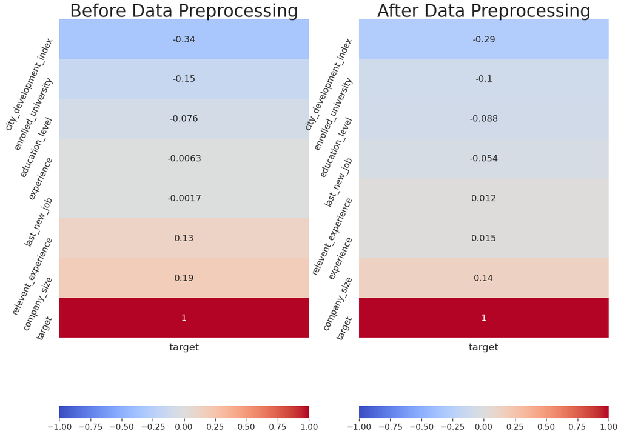

```python
fig, axes = plt.subplots(1, 2, figsize=(20, 17))


#fig.suptitle('Comparison of the feature correlation done before and after feature engineering', fontsize = 30)
g = sns.heatmap(df_initial.corr()[['target']].sort_values(by='target'),
                    annot=True,
                    cmap='coolwarm',
                    vmin=-1,
                    vmax=1 ,ax=axes[0], annot_kws={"size": 18} , cbar_kws={"orientation": "horizontal"},
               xticklabels=True, yticklabels=True)

g.set_yticklabels(g.get_yticklabels(), rotation=65,  fontsize = 17)
g.set_xticklabels(g.get_xticklabels(), rotation=0,  fontsize = 20)
axes[0].set_title('Before Data Preprocessing', fontsize=35)


f = sns.heatmap(df1_filled.corr()[['target']].sort_values(by='target'),
                    annot=True,
                    cmap='coolwarm',
                    vmin=-1,
                    vmax=1, ax=axes[1], annot_kws={"size": 18}, cbar_kws={"orientation": "horizontal"},
                xticklabels=True, yticklabels=True)

f.set_yticklabels(f.get_yticklabels(), rotation=65,  fontsize = 17)
f.set_xticklabels(f.get_xticklabels(), rotation=0,  fontsize = 20)


#labels = df1.columns
#f.set_yticklabels(df1, rotation = 65, fontsize = 14)
axes[1].set_title('After Data Preprocessing',fontsize=35)
```

What is better to better generalize or better fit the data? I will try to stick with the clustered one (df1_filled) because this may better generalize data and does not overfit.

The correlation might be not linear, sometimes it might be polynomial. Thus, to further investigate the influence of selected independent variables onot the target feature, we apply a tree based approach that can handle non linear correlations: Information gain feature selection.

```python
df1_filled.columns
```

```
Index(['city_development_index', 'relevent_experience', 'last_new_job',
       'target', 'enrolled_university', 'education_level', 'experience',
       'company_size'],
      dtype='object')
```

```python
#slecting the independent features with high correlation
df2 = df1_filled[['city_development_index', 'enrolled_university', 'relevent_experience', 'last_new_job', 'company_size',
           'target']]
```

```python
df2.head()
```

|  | city_development_index | enrolled_university | relevent_experience | last_new_job | company_size | target |
| --- | --- | --- | --- | --- | --- | --- |
| 0 | 0.827 | 0 | 0 | 1 | 3 | 1.0 |
| 1 | 0.920 | 2 | 0 | 1 | 4 | 1.0 |
| 2 | 0.624 | 2 | 1 | 0 | 4 | 0.0 |
| 3 | 0.827 | 2 | 0 | 1 | 3 | 1.0 |
| 4 | 0.920 | 2 | 0 | 5 | 0 | 1.0 |

```python
### Train test split to avoid overfitting
from sklearn.model_selection import train_test_split
X_train,X_test,y_train,y_test=train_test_split(df2.drop(labels=['target'], axis=1),
    df2['target'],
    test_size=0.3,
    random_state=0)
```

```python
from sklearn.feature_selection import mutual_info_classif
# determine the mutual information
mutual_info = mutual_info_classif(X_train, y_train)
mutual_info
```

```
array([0.05008992, 0.0071213 , 0.00162737, 0.00376774, 0.02086965])
```

```python
#create a dataframe with mutual selection
mutual_info = pd.Series(mutual_info)
mutual_info.index = X_train.columns
df_plot = pd.DataFrame(mutual_info.sort_values(ascending=False), columns = ['Score'])
```

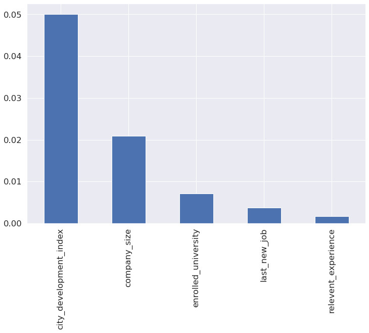

```python
#let's plot the ordered mutual_info values per feature
mutual_info.sort_values(ascending=False).plot.bar(figsize=(12, 8))
```

My hypostesis is confirmed: city_development_index is indeed the key feature for the prediction of the target variable

```python
df2.corr()
```

|  | city_development_index | enrolled_university | relevent_experience | last_new_job | company_size | target |
| --- | --- | --- | --- | --- | --- | --- |
| city_development_index | 1.000000 | 0.199870 | -0.061571 | 0.214881 | -0.102256 | -0.286326 |
| enrolled_university | 0.199870 | 1.000000 | -0.378154 | 0.237747 | -0.226037 | -0.099896 |
| relevent_experience | -0.061571 | -0.378154 | 1.000000 | -0.232180 | 0.317109 | 0.011510 |
| last_new_job | 0.214881 | 0.237747 | -0.232180 | 1.000000 | -0.201372 | -0.053925 |
| company_size | -0.102256 | -0.226037 | 0.317109 | -0.201372 | 1.000000 | 0.138870 |
| target | -0.286326 | -0.099896 | 0.011510 | -0.053925 | 0.138870 | 1.000000 |

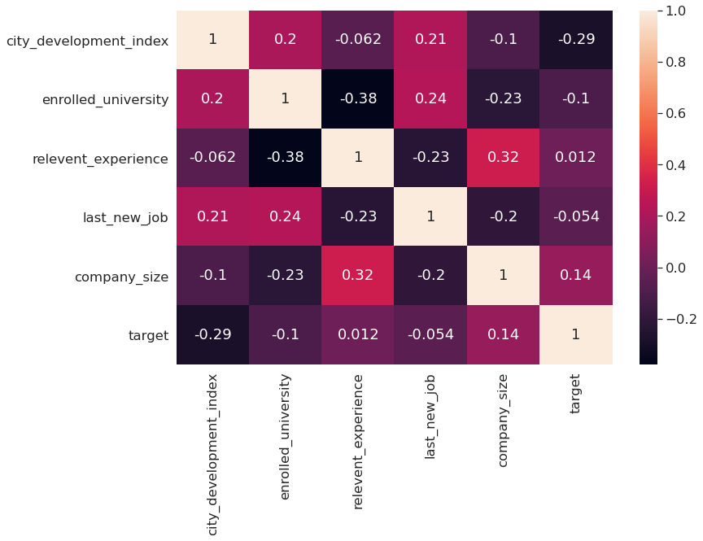

```python
sns.heatmap(df2.corr(), annot = True)
```

From the heatmap, we can see that some of the independent variables are correlated with each other resulting in multicollinearity curse. Even tough multicollinearity is not critical (<|0.5|), before applying any algorithms we need to calculate the feature [variance inflation factor (VIF)](https://statisticsbyjim.com/regression/variance-inflation-factors/) to decide whether to keep or to discard one feature from the correlated feature pair.

```python
#In case that there is a nulticollinearity between the selected independent variables
#We need to check the inflation factor to make sure we can use the features

#Lets scale the features
from sklearn.preprocessing import StandardScaler

sc = StandardScaler()
X_train_st = sc.fit_transform(X_train)
#X_test_std = sc_x.transform(X_test)


# Checking for the VIF values of the variables.
from statsmodels.stats.outliers_influence import variance_inflation_factor


# Creating a dataframe that will contain the names of all the feature variables and their VIFs
vif = pd.DataFrame()
vif['Features'] = X_train.columns
vif['VIF'] = [variance_inflation_factor(X_train_st, i) for i in range(X_train_st.shape[1])]
vif['VIF'] = round(vif['VIF'], 2)
vif = vif.sort_values(by = "VIF", ascending = False)
vif
```

|  | Features | VIF |
| --- | --- | --- |
| 2 | relevent_experience | 1.26 |
| 1 | enrolled_university | 1.24 |
| 4 | company_size | 1.15 |
| 3 | last_new_job | 1.14 |
| 0 | city_development_index | 1.09 |

Generally, any VIF values less that 2 is acceptable, so we keep all these features. Ideally it should be around 1